# ggplot2 Introduction

Li Zongzhang

2024-03-20

本章介绍ggplot2的用法。请先安装和加载包:tidyverse。

# 1 ggplot2概况

## 1.1 三个关键要素

- data 数据集
- aesthetic mapping 美学映射（图形的坐标系、颜色、形状等）
- layer 图层 geom函数

```r
library(ggplot2)
mpg
```

```
# A tibble: 234 × 11
   manufacturer model      displ  year   cyl trans drv     cty   hwy fl    class
   <chr>        <chr>      <dbl> <int> <int> <chr> <chr> <int> <int> <chr> <chr>
 1 audi         a4           1.8  1999     4 auto… f        18    29 p     comp…
 2 audi         a4           1.8  1999     4 manu… f        21    29 p     comp…
 3 audi         a4           2    2008     4 manu… f        20    31 p     comp…
 4 audi         a4           2    2008     4 auto… f        21    30 p     comp…
 5 audi         a4           2.8  1999     6 auto… f        16    26 p     comp…
 6 audi         a4           2.8  1999     6 manu… f        18    26 p     comp…
 7 audi         a4           3.1  2008     6 auto… f        18    27 p     comp…
 8 audi         a4 quattro   1.8  1999     4 manu… 4        18    26 p     comp…
 9 audi         a4 quattro   1.8  1999     4 auto… 4        16    25 p     comp…
10 audi         a4 quattro   2    2008     4 manu… 4        20    28 p     comp…
# ℹ 224 more rows
```

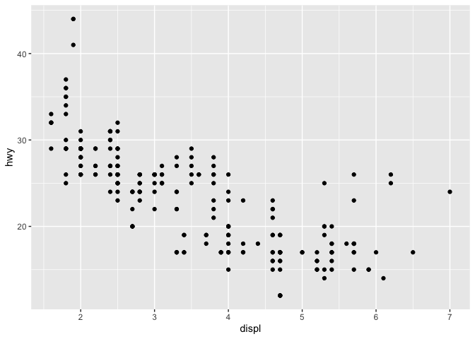

```r
#ggplot()第一项参数data = 指定数据集
#ggplot()第二项参数mapping = aes()  aesthetic
#aes()函数x = , y = 指定画布的坐标系

ggplot(data = mpg, mapping = aes(x = displ, y = hwy)) +
  geom_point()
```

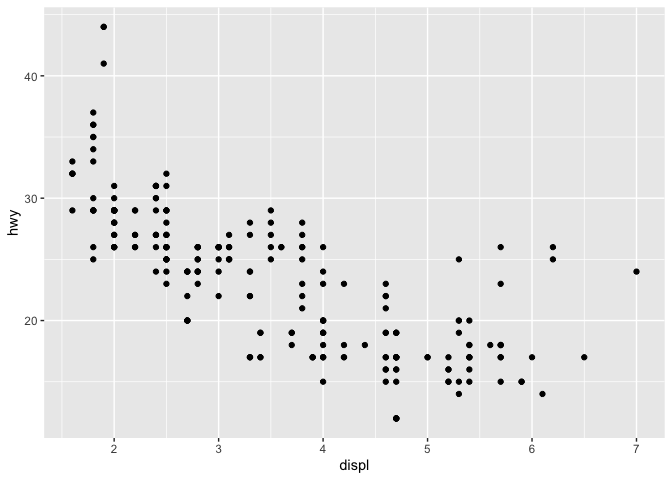

```r
#更加简洁的指令,data = 可以省略，mapping = 可以省略
ggplot(mpg, aes(displ, hwy)) +
  geom_point()
```

## 1.2 美学 Aesthetic: 颜色 形状 大小

若要在图形反映第3个变量的信息，可以在aes()函数中用第3个变量映射color, shape或size。

注意：颜色color、形状shape用定性变量映射，大小size用定量变量映射

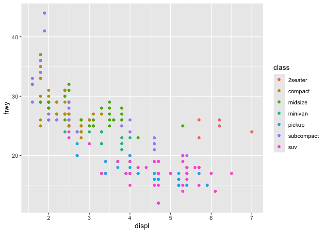

```r
#颜色用定性变量class映射，color = class
ggplot(mpg, aes(displ, hwy, col = class)) +
  geom_point()
```

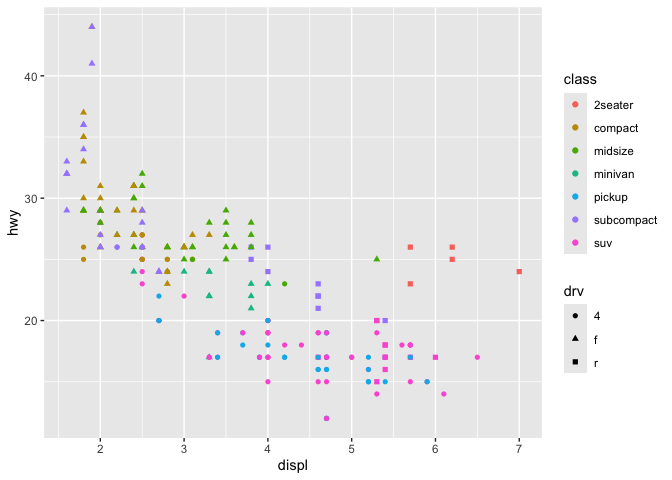

```r
#形状用定性变量drv映射，shape = drv
ggplot(mpg, aes(displ, hwy, shape = drv, color = class)) +
  geom_point()
```

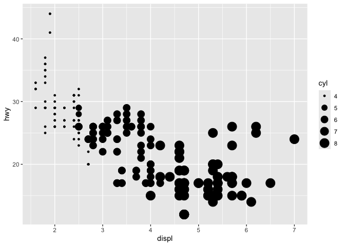

```r
#大小用定量变量cyl映射，size = cyl
ggplot(mpg, aes(displ, hwy, size = cyl)) +
  geom_point()
```

**思考：如果颜色用定量变量映射，效果如何？**

## 1.3 切面 Facet

在图形中引入定性变量，将样本分隔成几个子集/切面。

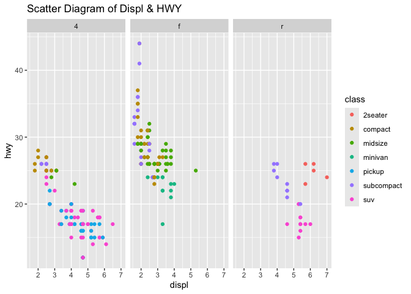

```r
#facet_wrap(～drv)按drv的三种取值，分为3个子集
ggplot(mpg, aes(displ, hwy,color = class)) +
  geom_point() +
  facet_wrap(~drv)+
  labs(title = "Scatter Diagram of Displ & HWY")
```

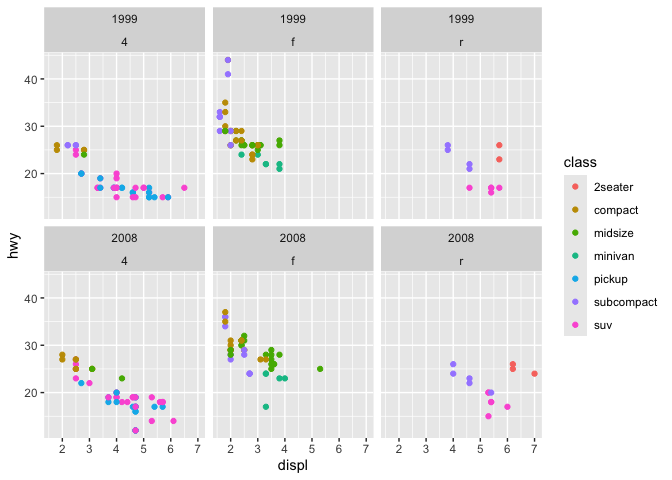

```r
#按两个定性变量切面
ggplot(mpg, aes(displ, hwy,color = class)) +
  geom_point() +
  facet_wrap(year ~ drv)
```

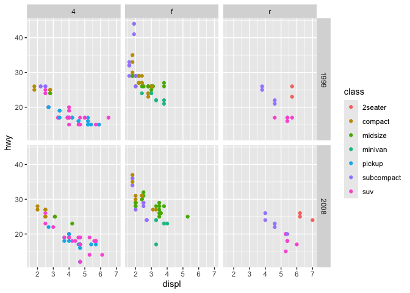

```r
#facet_grid 按两个定性变量切面
ggplot(mpg, aes(displ, hwy,color = class)) +
  geom_point() +
  facet_grid(year ~ drv)
```

# 2 管道符 pipe operator

**快捷键：Ctrl+Shift+M**

**优点：避免函数的嵌套**

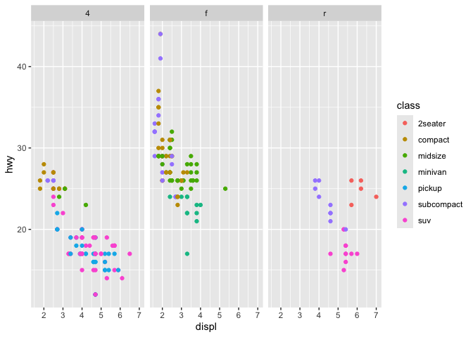

```r
#mpg 将作为ggplot()的第一项参数
mpg %>% ggplot(aes(displ, hwy,color = class)) +
  geom_point() +
  facet_wrap(~drv)
```

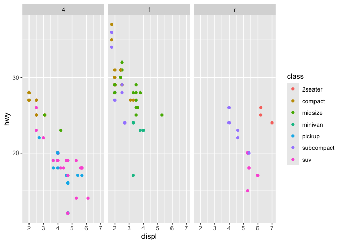

```r
# 使用管道符将 mpg 数据集中的 2008 年的数据筛选出来，并使用 ggplot 函数创建散点图，
# 其中 "displ" 作为 x 轴，"hwy" 作为 y 轴，"class" 作为颜色变量，"drv" 作为分面变量
mpg %>%
  filter(year==2008) %>% # 筛选数据
  ggplot(aes(displ, hwy,color = class)) + # 定义图形映射
  geom_point() + # 添加散点
  facet_wrap(~drv) # 分面展示
```

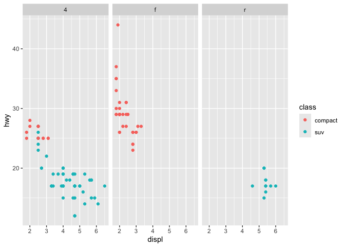

```r
# 使用管道符将 mpg 数据集中的 "compact" 和 "suv" 类别的数据筛选出来，并使用 ggplot 函数创建散点图，
# 其中 "displ" 作为 x 轴，"hwy" 作为 y 轴，"class" 作为颜色变量，"drv" 作为分面变量
mpg %>%
  filter(class == "compact" | class == "suv") %>% # 筛选数据
  ggplot(aes(displ, hwy,color = class)) + # 定义图形映射
  geom_point() + # 添加散点
  facet_wrap(~drv) # 分面展示
```

# 3 条形图

## 3.1 简单条形图

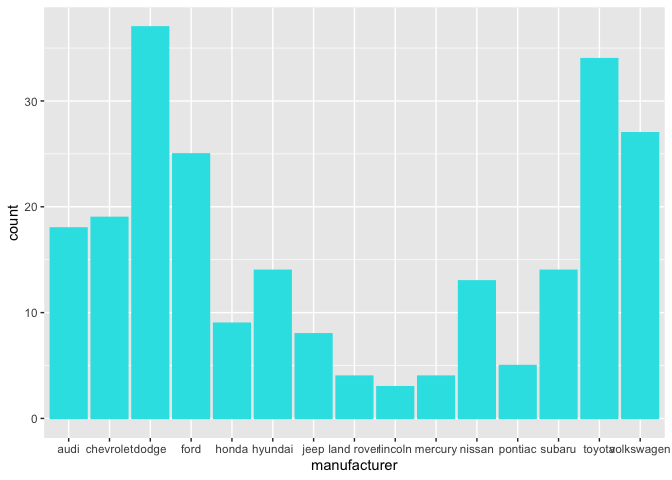

```r
# 使用管道符将 mpg 数据集作为 ggplot() 函数的输入，并将 "manufacturer" 列作为 x 轴
# 使用 geom_bar() 函数创建一个条形图
# col 参数设置条边颜色为5，fill 参数设置填充颜色为5
mpg %>%
  ggplot(aes(manufacturer)) +
  geom_bar(col = 5, fill = 5)
```

## 3.2 帕累托图

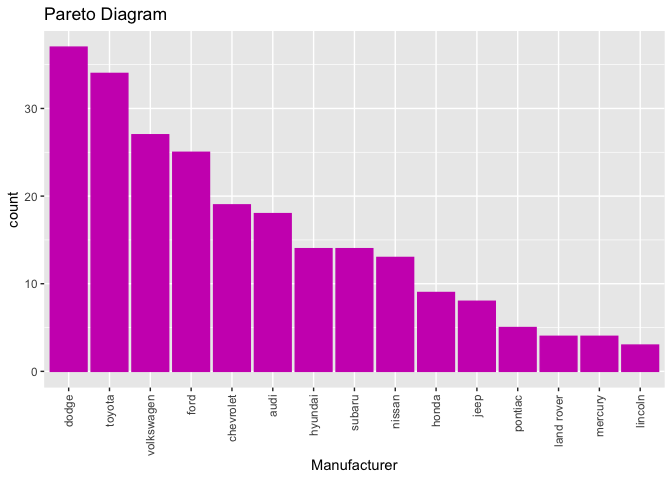

```r
# 使用 ggplot() 函数将 mpg 数据集作为输入，并将 "manufacturer" 列作为 x 轴变量，使用 fct_infreq() 函数将频数按降序排列
# 使用 geom_bar() 函数创建一个条形图
# col 参数设置条边颜色为6，fill 参数设置填充颜色为6
# 使用 guides() 函数设置 x 轴标签的角度
# guide_axis() 函数的 angle 参数设置标签的旋转角度
mpg %>% ggplot(aes(fct_infreq(manufacturer))) +
  geom_bar(col = 6, fill = 6)+
  guides(x = guide_axis(angle = 90))+
  labs(title = "Pareto Diagram", x = "Manufacturer")
```

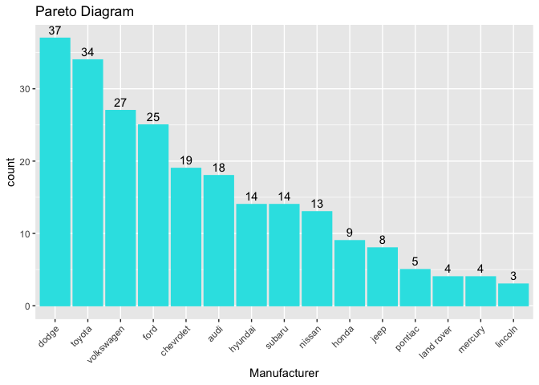

```r
#geom_text标注频数
mpg %>%     #使用管道操作符将mpg数据集传递到ggplot中
  ggplot(aes(fct_infreq(manufacturer))) + #指定图形的x轴为制造商，同时按照制造商出现频率排序
  geom_bar(col = 5, fill = 5)+            # 添加柱状图层，并指定边框颜色和填充颜色
  geom_text(stat = "count",               # 添加文本标签层，并指定使用计数统计信息作为标签
            aes(label = after_stat(count)), # 将标签内容设置为计数统计信息
            vjust = -0.5)+     # 将文本标签向下移动0.5个单位的文字高度
  guides(x = guide_axis(angle = 45))+
  labs(title = "Pareto Diagram", x = "Manufacturer")
```

## 3.3 分组条形图

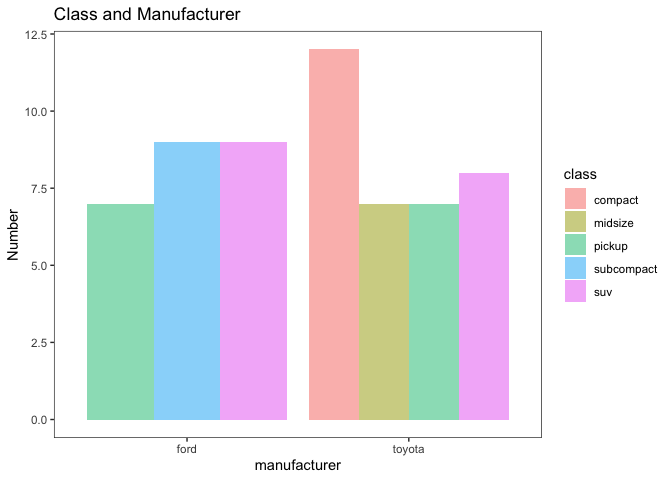

```r
# position = "dodge"  side by side bar plot
mpg %>%
  filter(manufacturer == "ford" | manufacturer == "toyota") %>%  # 筛选出制造商是 "ford" 或 "toyota" 的汽车数据
  ggplot(aes(manufacturer, fill = class)) +  # 创建一个 ggplot2 对象，以制造商为 x 轴，以车型为颜色填充
  geom_bar(position = "dodge", alpha = 0.5) +  # 绘制柱状图，position = "dodge" 表示分组柱状图，alpha = 0.5 表示透明度为 0.5
  theme_bw() +  # 设置绘图主题为黑白主题
  theme(panel.grid.major = element_blank(),  # 隐藏主网格线
        panel.grid.minor = element_blank()) +  # 隐藏次网格线
  labs(title = "Class and Manufacturer", x = "manufacturer", y = "Number")  # 设置图表的标题、x 轴标签和 y 轴标签
```

## 3.4 堆栈分组条形图

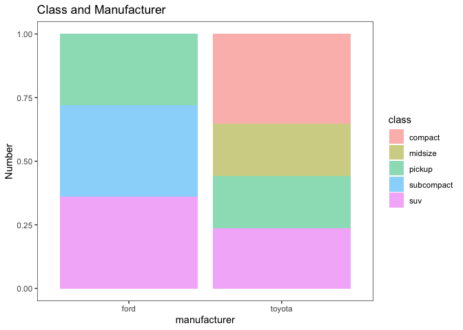

```r
#position = "fill" 堆栈
mpg %>%
  filter(manufacturer == "ford" | manufacturer == "toyota") %>%  # 筛选出制造商是 "ford" 或 "toyota" 的汽车数据
  ggplot(aes(manufacturer, fill = class)) +  # 创建一个 ggplot2 对象，以制造商为 x 轴，以车型为颜色填充
  geom_bar(position = "fill", alpha = 0.5) +  # 绘制柱状图，position = "fill" 表示堆叠柱状图，alpha = 0.5 表示透明度为 0.5
  theme_bw() +  # 设置绘图主题为黑白主题
  theme(panel.grid.major = element_blank(),  # 隐藏主网格线
        panel.grid.minor = element_blank()) +  # 隐藏次网格线
  labs(title = "Class and Manufacturer", x = "manufacturer", y = "Number")  # 设置图表的标题、x 轴标签和 y 轴标签
```

# 4 直方图

## 4.1 普通直方图

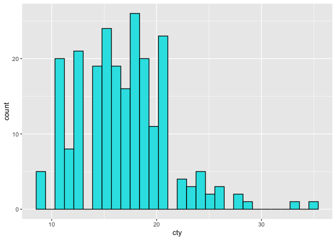

```r
#默认分30组
mpg %>%
  ggplot(aes(cty))+
  geom_histogram(col = 1, fill = 5)
```

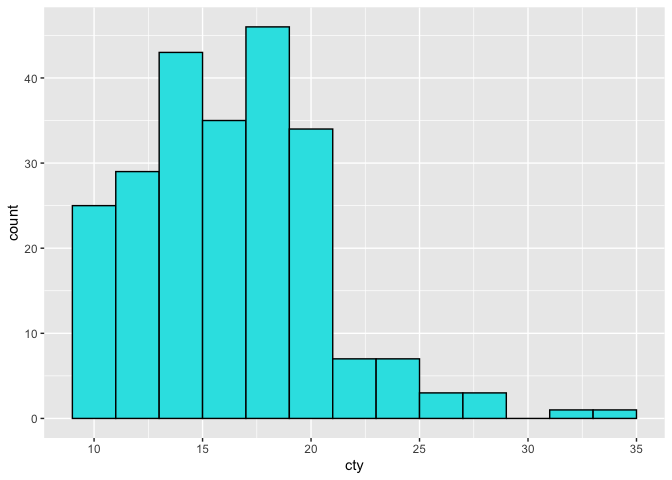

```r
#binwidth = 2 设置组距
mpg %>%
  ggplot(aes(cty))+
  geom_histogram(col = 1, fill = 5, binwidth = 2)
```

## 4.2 直方图上标注频数

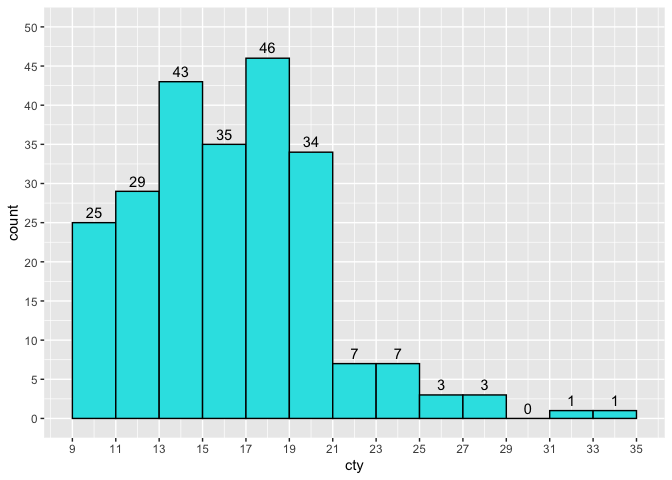

```r
mpg %>%
  ggplot(aes(cty))+
  geom_histogram(col = 1, fill = 5, binwidth = 2)+
  stat_bin(aes(label = after_stat(count)), binwidth = 2,
           geom = "text",vjust = -0.5)+
  scale_y_continuous(limits = c(0,50), breaks = seq(0,50,5))+
  scale_x_continuous(breaks = seq(9,35,2))
```

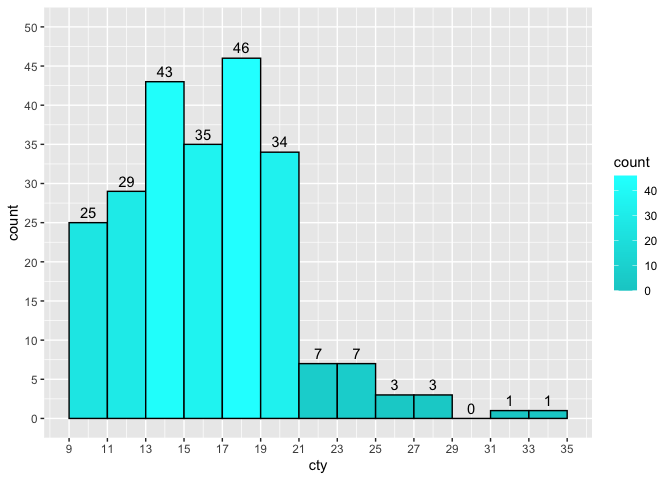

```r
#为直方图设置渐变填充色
mpg %>%
  ggplot(aes(cty))+
  geom_histogram(aes(fill = ..count..), col = 1, binwidth = 2)+
  stat_bin(aes(label = ..count..), binwidth = 2,
           geom = "text",vjust = -0.5)+
  scale_y_continuous(limits = c(0,50), breaks = seq(0,50,5))+
  scale_x_continuous(breaks = seq(9,35,2))+
  scale_fill_gradient(low = "cyan3", high = "cyan")
```

## 4.3 频数折线图

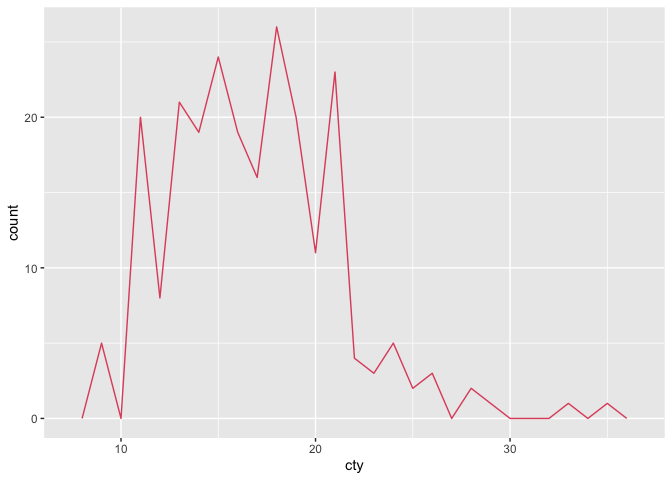

```r
#frequency polygon
mpg %>%
  ggplot(aes(cty))+
    geom_freqpoly(col = 2,binwidth = 1)
```

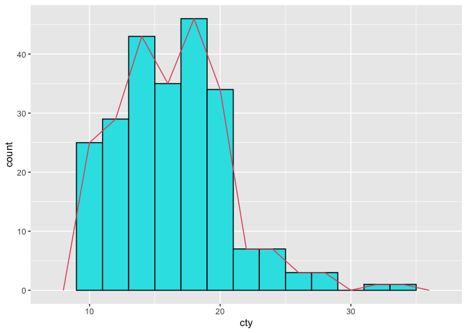

```r
#在直方图上添加频数折线图
mpg %>%
  ggplot(aes(cty))+
  geom_histogram(col = 1, fill = 5, binwidth = 2)+
  geom_freqpoly(col = 2,binwidth = 2)
```

## 4.4 分组直方图

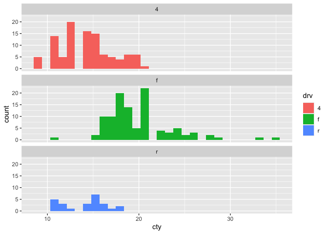

```r
#facet_wrap 切面，各个组别填充不同颜色
mpg %>%
  ggplot(aes(cty, fill = drv))+
  geom_histogram()+
  facet_wrap(~drv, ncol = 1)
```

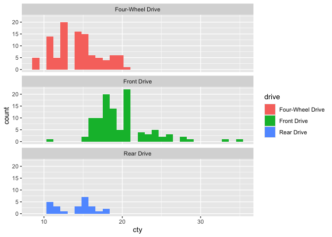

```r
#在mpg中追加新变量drive
#recode对变量重新编码
mpg <- mpg %>%
  mutate(drive = recode(drv,"f" ="Front Drive", "r" = "Rear Drive",
                      "4" = "Four-Wheel Drive"))

mpg %>%
  ggplot(aes(cty, fill = drive))+
  geom_histogram()+
  facet_wrap(~drive, ncol = 1)
```

## 4.5 分组直方图标注频数

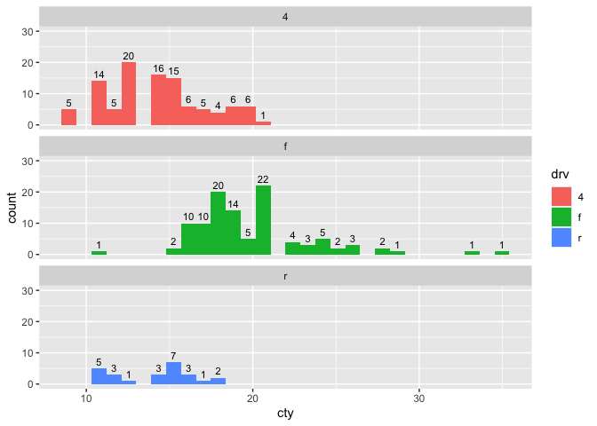

```r
mpg %>%
  ggplot(aes(cty, fill = drv))+
  geom_histogram()+
  facet_wrap(~drv, ncol = 1)+
  stat_bin(aes(label =ifelse(..count.. == 0, "", ..count..)),
           geom = "text",
           vjust = -0.5,
           size = 3)+
  scale_y_continuous(limits = c(0,30))
```

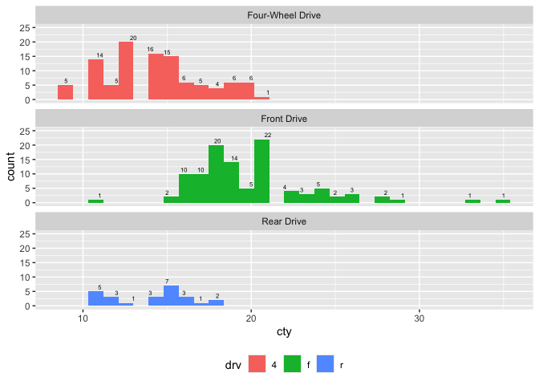

```r
#geom_text()标注频数
mpg %>%
  ggplot(aes(cty, fill = drv))+
  geom_histogram()+
  facet_wrap(~drive, ncol = 1)+
  geom_text(stat = "count",
            aes(label = ..count.., y = ..count..),
            vjust = -0.5,
            hjust = 0.5,
            size = 2)+
  scale_y_continuous(limits = c(0, 25))+
  theme(legend.position = "bottom")
```

## 4.6 分组频数折线图

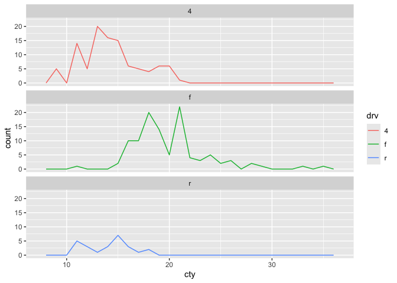

```r
#frequency polygon
mpg %>%
  ggplot(aes(cty, col = drv))+
    geom_freqpoly(binwidth = 1)+
  facet_wrap(~drv, ncol = 1)
```

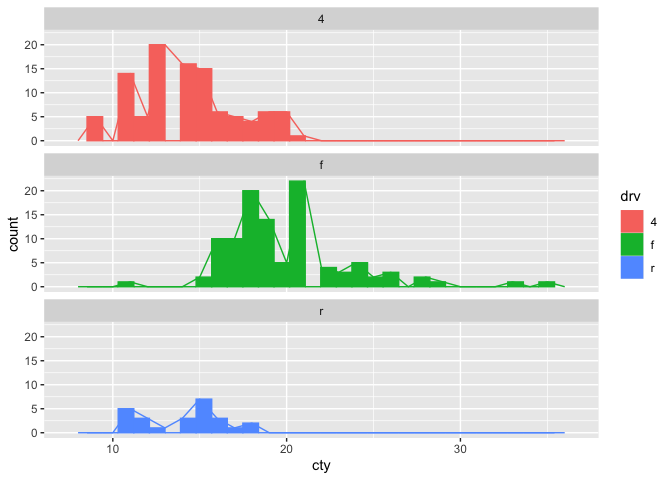

```r
mpg %>%
  ggplot(aes(cty, col = drv, fill = drv))+
  geom_histogram()+
  geom_freqpoly(binwidth = 1)+
  facet_wrap(~drv, ncol = 1)
```

# 5 箱线图

## 5.1 普通箱线图

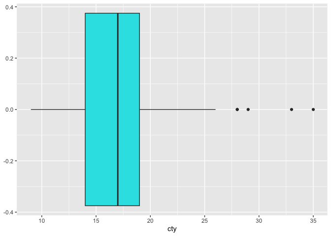

```r
mpg %>%
  ggplot(aes(cty))+
  geom_boxplot(fill = 5)
```

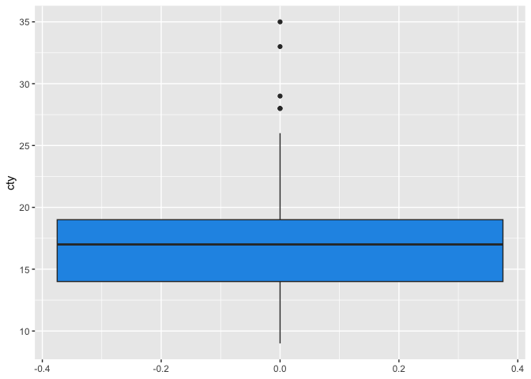

```r
#垂直放置   coord_flip()
mpg %>%
  ggplot(aes(cty))+
  geom_boxplot(fill = 4)+
  coord_flip()
```